# Assessing patient-reported outcomes, pharmacist interventions and medication adherence in inflammatory bowel disease

Ryan Moore

Leena Choi

Department of Biostatistics

Vanderbilt University Medical Center

2022-09-12

# 1 Study Details

## 1.1 Study title

**Assessing patient-reported outcomes, pharmacist interventions and medication adherence in inflammatory bowel disease**

## 1.2 Background

Patient reported outcomes (PROs), defined as a measurement of any aspect of a patient’s health status that comes directly from the patient, are an effective took for understanding patient insights into their disease management, quality of life and functioning and can help inform clinical decision making and improve quality of care. VSP’s current workflow captures specific PROs during monthly refill assessments and alerts the pharmacist of any negative findings. An integrated clinic pharmacist then performs a variety of interventions to facilitate medication adherence and identify medication safety or effectiveness or further coordination of care.

## 1.3 Objectives

- Quantify patient-reported response to therapy
- Quantify number and type of pharmacist interventions performed during monthly refill assessments.

## 1.4 Inclusion criteria

- Patients with at least two medication fills through VSP between January and March 2020
- Prescribed specialty therapy by a VUMC inflammatory bowel disease clinic provider.
- Patient associated with the Adult GI/IBD clinic

# 2 Descriptive Statistics

## 2.1 Demographics and patient characteristics

| Demographics and patient characteristics | Demographics and patient characteristics N | Demographics and patient characteristics *N=181* |
| --- | --- | --- |
| Age at start | 181 | 33 42 55 (44 ±15) |
| Gender | 181 |  |
| Female |  | 52% (95) |
| Male |  | 48% (86) |
| Race | 181 |  |
| White |  | 92.3% (167) |
| Black or African American |  | 5.0% ( 9) |
| Other Asian |  | 1.7% ( 3) |
| Other |  | 0.6% ( 1) |
| Unknown |  | 0.6% ( 1) |
| Ethnicity | 181 |  |
| Not Hispanic, Latino/a, or Spanish origin |  | 93.9% (170) |
| Unknown |  | 2.2% ( 4) |
| Decline to Answer |  | 1.7% ( 3) |
| Other Hispanic, Latino/a, or Spanish origin |  | 2.2% ( 4) |
| Insurance Type | 181 |  |
| Commercial |  | 77.3% (140) |
| Medicare |  | 18.2% ( 33) |
| Medicaid |  | 2.2% ( 4) |
| Other |  | 2.2% ( 4) |
| Other insurance | 181 |  |
| J&J Patient Assistance |  | 2.2% ( 4) |
| NA |  | 97.8% (177) |
| Patient status | 181 |  |
| Living |  | 100% (181) |
| Indication | 181 |  |
| Crohn's Disease |  | 87% (158) |
| Ulcerative Colitis |  | 13% ( 23) |
| Previous IBD surgery | 181 |  |
| 0 |  | 55.8% (101) |
| 1 |  | 18.8% ( 34) |
| 2 |  | 12.7% ( 23) |
| 3 |  | 6.6% ( 12) |
| 4 |  | 3.3% ( 6) |
| 5 |  | 1.1% ( 2) |
| 6 |  | 1.1% ( 2) |
| 7 |  | 0.6% ( 1) |
| Specialty GI med | 181 |  |
| Cimzia (certolizumab) |  | 3.3% ( 6) |
| Humira (adalimumab) |  | 57.5% (104) |
| Simponi (golimumab) |  | 3.3% ( 6) |
| Stelara (ustekinumab) |  | 31.5% ( 57) |
| Xeljanz/Xeljanz XR (tofacitinib) |  | 4.4% ( 8) |
| Administration route | 181 |  |
| Oral |  | 4.4% ( 8) |
| Subcutaneous |  | 95.6% (173) |
| IBD surgery | 181 |  |
| Yes |  | 42% ( 77) |
| No |  | 58% (104) |

*a* *b* *c* represent the lower quartile *a*, the median *b*, and the upper quartile *c* for continuous variables. *x ± s* represents X ± 1 SD. *N* is the number of non-missing values. Numbers after proportions are frequencies.

## 2.2 Disease states and medications

| Disease states and medications | Disease states and medications N | Disease states and medications Crohn's Disease *N=158* | Disease states and medications Ulcerative Colitis *N=23* |
| --- | --- | --- | --- |
| Previous IBD surgery | 181 |  |  |
| 0 |  | 50.0% (79) | 95.7% (22) |
| 1 |  | 21.5% (34) | 0.0% ( 0) |
| 2 |  | 13.9% (22) | 4.3% ( 1) |
| 3 |  | 7.6% (12) | 0.0% ( 0) |
| 4 |  | 3.8% ( 6) | 0.0% ( 0) |
| 5 |  | 1.3% ( 2) | 0.0% ( 0) |
| 6 |  | 1.3% ( 2) | 0.0% ( 0) |
| 7 |  | 0.6% ( 1) | 0.0% ( 0) |
| Specialty GI med | 181 |  |  |
| Cimzia (certolizumab) |  | 3.8% ( 6) | 0.0% ( 0) |
| Humira (adalimumab) |  | 56.3% (89) | 65.2% (15) |
| Simponi (golimumab) |  | 0.6% ( 1) | 21.7% ( 5) |
| Stelara (ustekinumab) |  | 35.4% (56) | 4.3% ( 1) |
| Xeljanz/Xeljanz XR (tofacitinib) |  | 3.8% ( 6) | 8.7% ( 2) |
| Administration route | 181 |  |  |
| Oral |  | 3.8% ( 6) | 8.7% ( 2) |
| Subcutaneous |  | 96.2% (152) | 91.3% ( 21) |
| IBD surgery | 181 |  |  |
| Yes |  | 48.1% (76) | 4.3% ( 1) |
| No |  | 51.9% (82) | 95.7% (22) |
| Ulcerative colitis extent | 181 |  |  |
| proctitis |  | 0% ( 0) | 17% ( 4) |
| left sided |  | 0% ( 0) | 30% ( 7) |
| pancolitis |  | 0% ( 0) | 52% ( 12) |
| NA |  | 100% (158) | 0% ( 0) |
| Crohn's extent | 181 |  |  |
| ileal |  | 4.4% ( 7) | 0.0% ( 0) |
| colonic |  | 19.6% (31) | 0.0% ( 0) |
| both small bowel and colonic |  | 36.7% (58) | 0.0% ( 0) |
| small bowel only |  | 21.5% (34) | 0.0% ( 0) |
| all sites |  | 17.7% (28) | 0.0% ( 0) |
| NA |  | 0.0% ( 0) | 100.0% (23) |
| Perianal IBD | 181 |  |  |
| Yes |  | 38% (60) | 0% ( 0) |
| No |  | 62% (98) | 0% ( 0) |
| NA |  | 0% ( 0) | 100% (23) |
| Fistulizing disease | 181 |  |  |
| Yes |  | 47% (74) | 0% ( 0) |
| No |  | 53% (84) | 0% ( 0) |
| NA |  | 0% ( 0) | 100% (23) |
| Stricturing disease | 181 |  |  |
| Yes |  | 44% (69) | 0% ( 0) |
| No |  | 56% (89) | 0% ( 0) |
| NA |  | 0% ( 0) | 100% (23) |

*N* is the number of non-missing values. Numbers after proportions are frequencies.

Count of IBD biologics per patient

| Number of previous biologics | Count |
| --- | --- |
| 1 | 118 |
| 2 | 31 |
| 3 | 19 |
| 5 | 6 |
| 4 | 5 |
| 6 | 2 |

# 3 MRQ Data

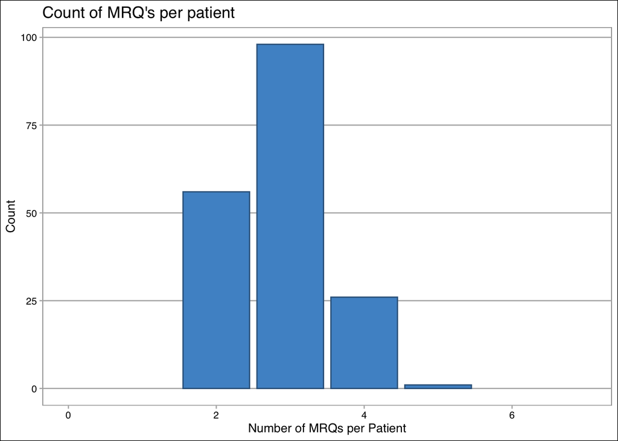

## 3.1 Missed Doses

### 3.1.1 Count of missed doses

#### 3.1.1.1 Per Patient

| Number of missed doses per patient. | Number of missed doses per patient. *N=181* |
| --- | --- |
| Number of Missed Doses |  |
| 0 | 0.94 (170) |
| 1 | 0.06 ( 11) |

Numbers after proportions are frequencies.

#### 3.1.1.2 In last month per MRQ

| Number of missed doses in the last month per MRQ. | Number of missed doses in the last month per MRQ. *N=515* |
| --- | --- |
| Number of missed doses |  |
| 1-2 doses | 0.02 ( 11) |
| No missed doses | 0.98 (504) |

Numbers after proportions are frequencies.

### 3.1.2 Reasons for missed doses

Reasons for Missed Doses

| Reasons | Frequency |
| --- | --- |
| Patient was in Hospital | 4 |
| Purposefully Held Due to Illness or Procedure | 3 |
| Forgetfulness | 2 |
| Other | 2 |
| Ran Out of Medication | 1 |

## 3.2 Patient Perceived Efficacy

### 3.2.1 Table

| Patient reported medication effectiveness. | Patient reported medication effectiveness. *N=515* |
| --- | --- |
| Effectiveness |  |
| Fair | 0.02 ( 10) |
| Good | 0.84 (434) |
| Excellent | 0.13 ( 69) |
| NA | 0.00 ( 2) |

Numbers after proportions are frequencies.

### 3.2.2 Visualization

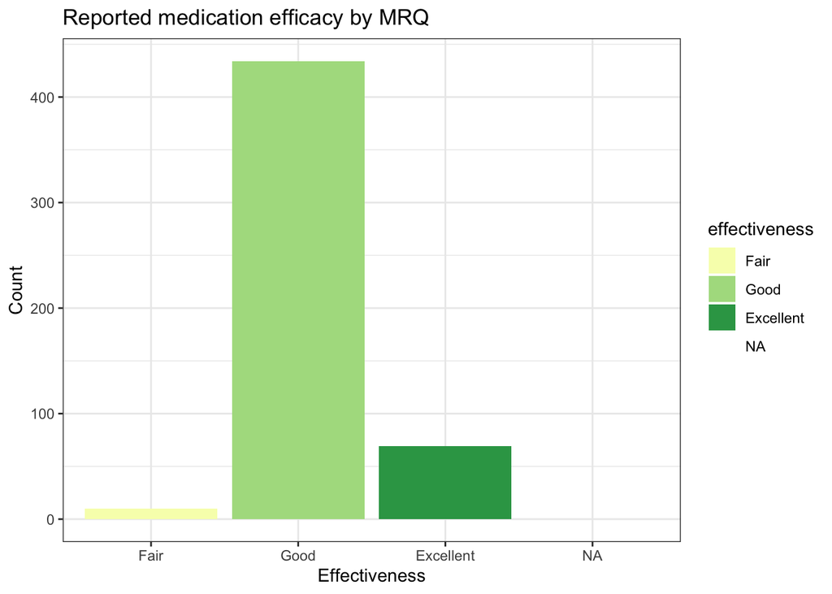

# 4 Pharmacist Interventions

## 4.1 Count of interventions

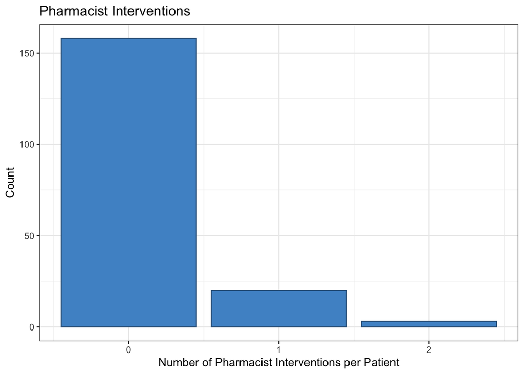

## 4.2 Types of Interventions

Count of types of pharmacist interventions by intervention

| Interventions | Frequency |
| --- | --- |
| Adherence/Missed Dose | 12 |
| ED/Hospitalization/Urgent Care Visit | 9 |
| Therapeutic Monitoring - Efficacy | 6 |
| Medication List Change | 3 |
| Condition-Related Concern or Exacerbation | 2 |
| Common Side Effect/Toxicity | 1 |
| Drug Administration Question | 1 |
| New Condition or Diagnosis Identified | 1 |

## 4.3 Outcomes of Interventions

Total count of outcomes of pharmacist interventions by intervention

| Interventions | Frequency |
| --- | --- |
| Identified Issue Resolved | 18 |
| Medication Administration Held | 1 |
| Recommendation to Provider Accepted | 1 |
| Unknown | 7 |

# 5 IBD Outcomes

## 5.1 Outcomes per patient

Number of PRO and Labs per patient

| . | Freq |
| --- | --- |
| 1 | 17 |
| 2 | 60 |
| 3 | 60 |
| 4 | 18 |
| 5 | 6 |
| 6 | 12 |
| 7 | 4 |
| 8 | 2 |
| 9 | 1 |

## 5.2 Summary Statistics of outcomes

| Outcomes at PRO level | Outcomes at PRO level N | Outcomes at PRO level Crohn's Disease *N=481* | Outcomes at PRO level Ulcerative Colitis *N=63* |
| --- | --- | --- | --- |
| IBD Subset Score | 349 | 2 11 19 (13 ±11) | 0 0 0 ( 0 ± 0) |
| PHQ9 Score | 418 | 1.0 3.0 7.0 (4.2 ±4.3) | 0.0 1.0 3.0 (2.4 ±3.3) |
| CRP | 374 | 0.8 2.6 7.7 ( 9.0 ±20.7) | 0.4 0.7 2.5 ( 2.7 ± 5.4) |
| SIBDQ | 417 | 50.0 58.0 62.0 (55.5 ± 9.1) | 57.5 62.0 64.5 (60.6 ± 7.3) |
| HBI | 356 | 1.0 3.0 6.0 (4.1 ±3.9) | 0.0 0.0 0.0 (0.0 ±0.0) |

*a* *b* *c* represent the lower quartile *a*, the median *b*, and the upper quartile *c* for continuous variables. *x ± s* represents X ± 1 SD. *N* is the number of non-missing values.

## 5.3 Outcomes over time

### 5.3.1 HBI

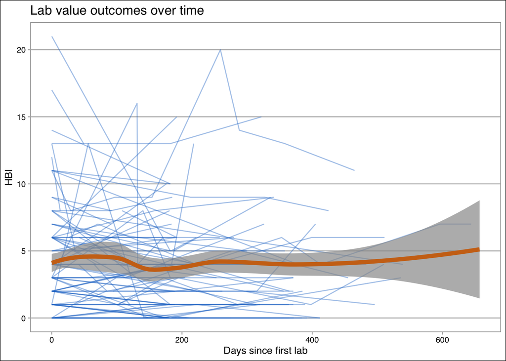

### 5.3.2 SIBDQ

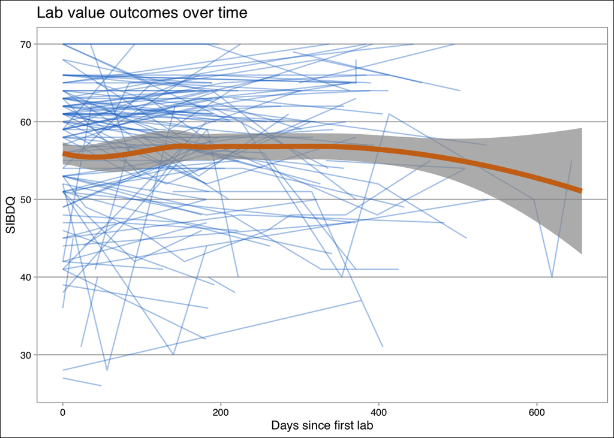

### 5.3.3 PHQ9

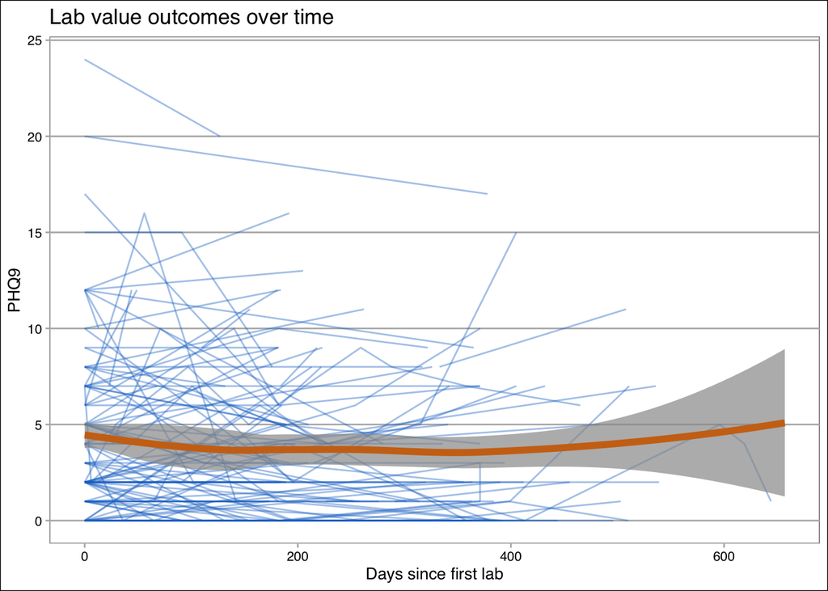

### 5.3.4 IBD Subset

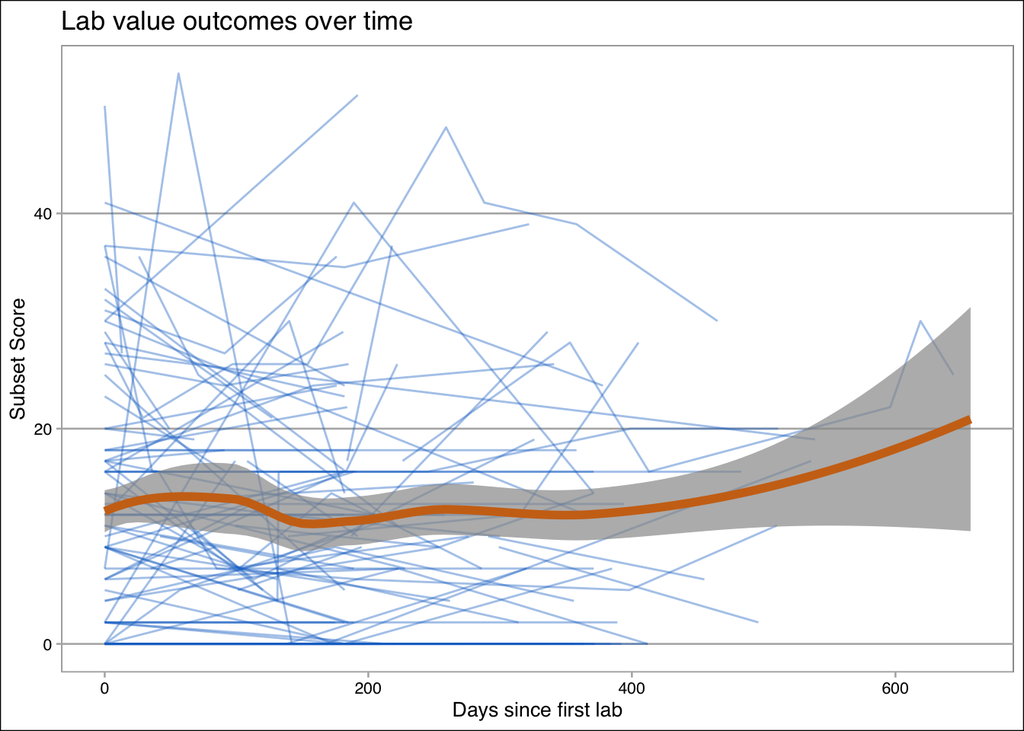

### 5.3.5 CRP

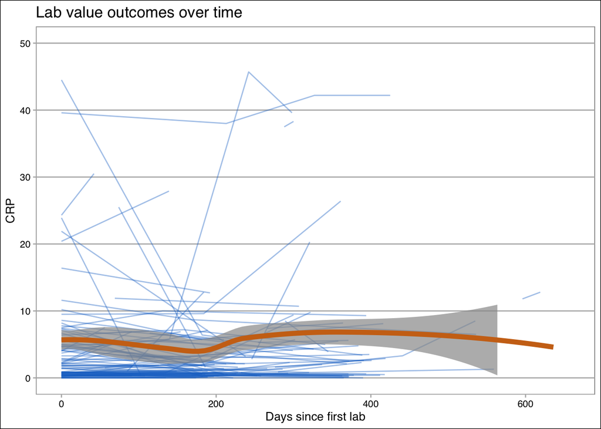